# Numeracy

# 1 Description of DataSchema variable

The description of harmonised variable is the following:

- Short name: `cog_num`
- Variable label: `Cognition - numeracy test`
- Variable description: `Test composed by several numeracy questions. Variable dichotomised by first quartil with value 0 and higher with value 1. Presence of difficulties on numeracy questions (everyday maths problems)`
- Domain: `Health status and functional limitations`
- Value type: `categorical`
- Category coding:

| **Code** | **Category Label** |
| --- | --- |
| 0 | <=25% |
| 1 | >25% |

- Category missings:

| **Code** | **Category Label** |
| --- | --- |
| 991 | CAPI/interviewer error |
| 992 | Impute |
| 993 | Disable to measure |
| 994 | Not attempt/not done |
| 995 | Does not answer |
| 996 | Not applicable |
| 997 | Refuse |
| 998 | Do not know |
| 999 | Missing |

- Short name: `cog_num_c`
- Variable label: `Cognition - numeracy test. Continuous variable`
- Variable description: `It is assessed by means of a numeracy test composed by several numeracy questions. Presence of difficulties on numeracy questions (everyday maths problems)`
- Domain: `Health status and functional limitations`
- Value type: `continuous`
- Category missings:

| **Code** | **Category Label** |
| --- | --- |
| 991 | CAPI/interviewer error |
| 992 | Impute |
| 993 | Disable to measure |
| 994 | Not attempt/not done |
| 995 | Does not answer |
| 996 | Not applicable |
| 997 | Refuse |
| 998 | Do not know |
| 999 | Missing |

# 2 Data process

## 2.1 England

### 2.1.1 Wave 1

#### 2.1.1.1 Study-specific variable description

| **Name** | `cfmscr` |
| --- | --- |
| **Label** | `Computed score from numeracy questions (0-6)` |
| **Table name** | `wave_1_core_data_v3` |
| **Missings** | `-9 = Refusal` `-8 = Don't know` `-1 = Not applicable` |
| **Description** |  |

cfmscr

| Sample size | Missing values |
| --- | --- |
| 12099 | 215 |

Values

|  | No-missings | -9 | -8 | -1 | NA |
| --- | --- | --- | --- | --- | --- |
| Frequency | 11884.00 | 0 | 0 | 215.00 | 0 |
| Percentage | 98.22 | 0 | 0 | 1.78 | 0 |

Summary

| Min. | 1st Qu. | Median | Mean | 3rd Qu. | Max. |
| --- | --- | --- | --- | --- | --- |
| 0 | 3 | 4 | 3.885 | 5 | 6 |

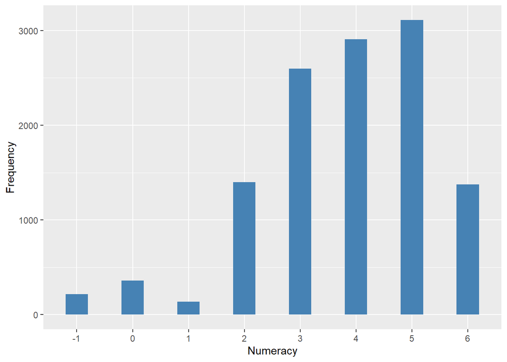

#### 2.1.1.2 Harmonisation algorithm

To compute the harmonize variable `cog_num_c` from the study-specific variable the missing values have to be recoded as follows:

- `-1 'Not applicable' into 996`
- `-9 'Refusal' into 997`
- `-8 'Don't Know' into 998`

To compute the harmonized variable `cog_num` from `cog_num_c` it has to be recoded as follows:

- `<=25% into 0`
- `>25% into 1`

**R script:**

```r
# cog_num_c
ELSA_ds_w1 <- tibble(id = ELSA_w1_cog_num$id)
ELSA_ds_w1$cog_num_c <- car::recode(ELSA_w1_cog_num$cfmscr, "-9=997; -8=998; -1=996; NA=999")
ELSA_ds_w1$cog_num_c <- labelled(ELSA_ds_w1[[2]], labels = c(Missing = 999,
    `Do not know` = 998, Refuse = 997, `Not applicable` = 996, `Does not answer` = 995,
    `Not attempt not done` = 994, `Disable to measure` = 993, Impute = 992,
    `CAPI interviewer error` = 991))

Q <- quantile(car::recode(ELSA_ds_w1$cog_num_c, "999=NA;997=NA;996=NA;998=NA"),
    probs = 1/4, na.rm = TRUE, names = FALSE)

# cog_num
ELSA_ds_w1$cog_num <- car::recode(ELSA_ds_w1$cog_num_c, "0:Q=0; (Q+1):900=1")
ELSA_ds_w1$cog_num <- labelled(ELSA_ds_w1[[3]], labels = c(`<=25%` = 0, `>25%` = 1,
    Missing = 999, `Do not know` = 998, Refuse = 997, `Not applicable` = 996,
    `Does not answer` = 995, `Not attempt not done` = 994, `Disable to measure` = 993,
    Impute = 992, `CAPI interviewer error` = 991))
```

#### 2.1.1.3 Statistical description of the new harmonised variable

Cognition - numeracy test, composed by several numeracy questions

| Sample size | Missing values |
| --- | --- |
| 12099 | 215 |

Values

|  | No-missings | 991 | 992 | 993 | 994 | 995 | 996 | 997 | 998 | 999 | NA |
| --- | --- | --- | --- | --- | --- | --- | --- | --- | --- | --- | --- |
| Frequency | 11884.00 | 0 | 0 | 0 | 0 | 0 | 215.00 | 0 | 0 | 0 | 0 |
| Percentage | 98.22 | 0 | 0 | 0 | 0 | 0 | 1.78 | 0 | 0 | 0 | 0 |

Summary

| Min. | 1st Qu. | Median | Mean | 3rd Qu. | Max. |
| --- | --- | --- | --- | --- | --- |
| 0 | 3 | 4 | 3.885 | 5 | 6 |

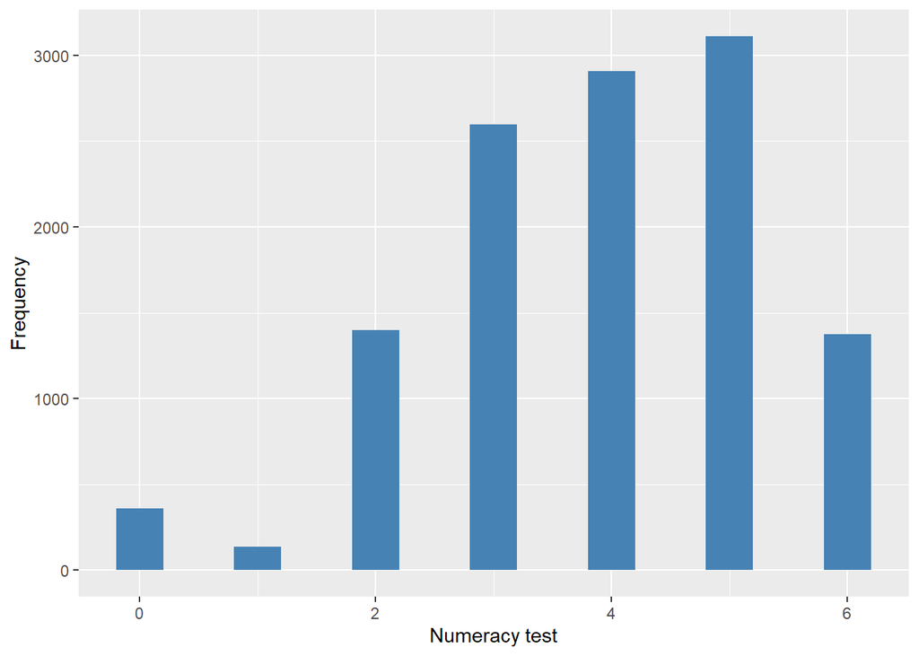

Cognition - numeracy test, composed by several numeracy questions. Discrete variable: value 0 = <=25%; value 1 = >25%

| Sample size | Missing values |
| --- | --- |
| 12099 | 215 |

Category

|  | 0 | 1 |
| --- | --- | --- |
| Frequency | 4490.00 | 7394.00 |
| Percentage | 37.11 | 61.11 |

Type of missing

|  | 991 | 992 | 993 | 994 | 995 | 996 | 997 | 998 | 999 | NA |
| --- | --- | --- | --- | --- | --- | --- | --- | --- | --- | --- |
| Frequency | 0 | 0 | 0 | 0 | 0 | 215.00 | 0 | 0 | 0 | 0 |
| Percentage | 0 | 0 | 0 | 0 | 0 | 1.78 | 0 | 0 | 0 | 0 |

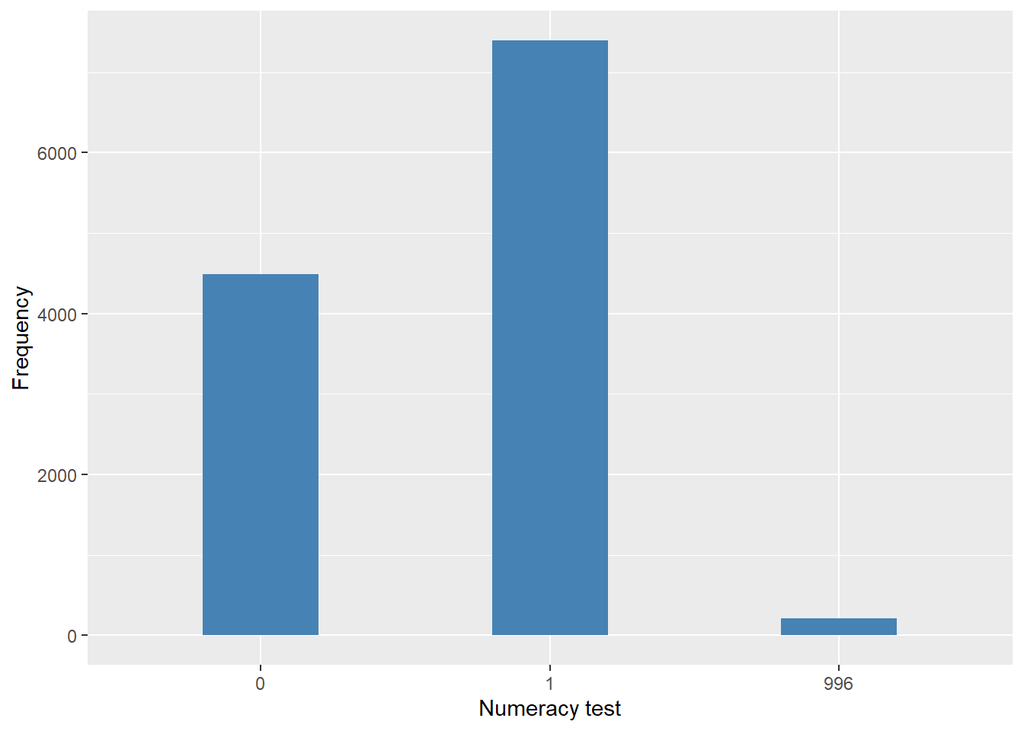

#### 2.1.1.4 Validation

### 2.1.2 Wave 2

There is no variable.

### 2.1.3 Wave 3

There is no variable.

### 2.1.4 Wave 4

#### 2.1.4.1 Study-specific variable description

| **Name** | `cfmscr` |
| --- | --- |
| **Label** | `Computed score from numeracy questions (0-6)` |
| **Table name** | `wave_4_elsa_data_v3` |
| **Missings** | `-9 = Refusal` `-8 = Don't know` `-1 = Not applicable` |
| **Description** |  |

cfmscr

| Sample size | Missing values |
| --- | --- |
| 11050 | 516 |

Values

|  | No-missings | -9 | -8 | -1 | NA |
| --- | --- | --- | --- | --- | --- |
| Frequency | 10534.00 | 70.00 | 0 | 446.00 | 0 |
| Percentage | 95.33 | 0.63 | 0 | 4.04 | 0 |

Summary

| Min. | 1st Qu. | Median | Mean | 3rd Qu. | Max. |
| --- | --- | --- | --- | --- | --- |
| 0 | 3 | 4 | 4.155 | 5 | 6 |

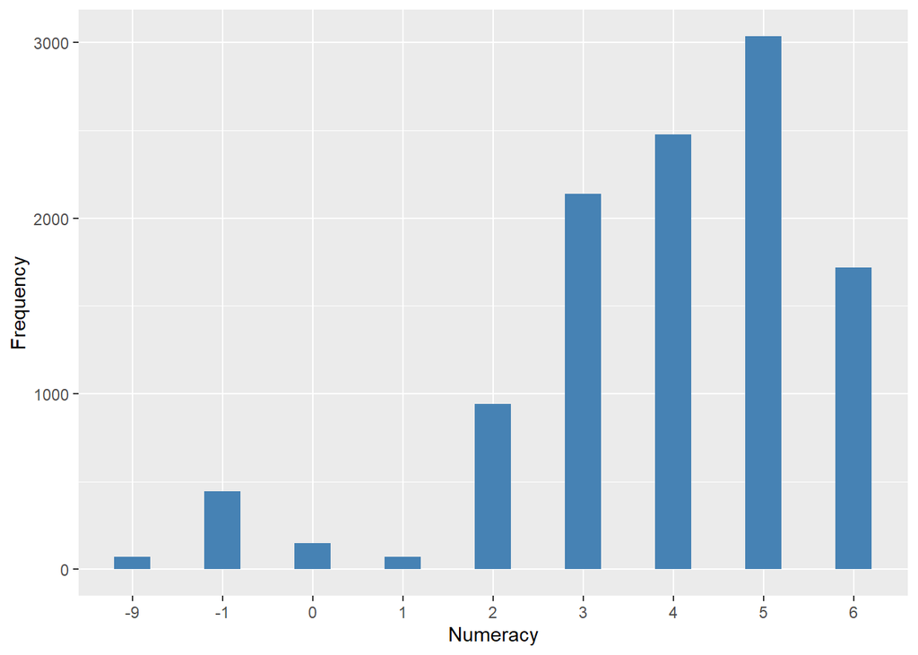

#### 2.1.4.2 Harmonisation algorithm

To compute the harmonize variable `cog_num_c` from the study-specific variable the missing values have to be recoded as follows:

- `-1 'Not applicable' into 996`
- `-9 'Refusal' into 997`
- `-8 'Don't Know' into 998`

To compute the harmonized variable `cog_num` from `cog_num_c` it has to be recoded as follows:

- `<=25% into 0`
- `>25% into 1`

**R script:**

```r
# cog_num_c
ELSA_ds_w4 <- tibble(id = ELSA_w4_cog_num$id)
ELSA_ds_w4$cog_num_c <- car::recode(ELSA_w4_cog_num$cfmscr, "-9=997; -8=998; -1=996; NA=999")
ELSA_ds_w4$cog_num_c <- labelled(ELSA_ds_w4[[2]], labels = c(Missing = 999,
    `Do not know` = 998, Refuse = 997, `Not applicable` = 996, `Does not answer` = 995,
    `Not attempt not done` = 994, `Disable to measure` = 993, Impute = 992,
    `CAPI interviewer error` = 991))

Q <- quantile(car::recode(ELSA_ds_w4$cog_num_c, "999=NA;997=NA;996=NA;998=NA"),
    probs = 1/4, na.rm = TRUE, names = FALSE)

# cog_num
ELSA_ds_w4$cog_num <- car::recode(ELSA_ds_w4$cog_num_c, "0:Q=0; (Q+1):900=1")
ELSA_ds_w4$cog_num <- labelled(ELSA_ds_w4[[3]], labels = c(`<=25%` = 0, `>25%` = 1,
    Missing = 999, `Do not know` = 998, Refuse = 997, `Not applicable` = 996,
    `Does not answer` = 995, `Not attempt not done` = 994, `Disable to measure` = 993,
    Impute = 992, `CAPI interviewer error` = 991))
```

#### 2.1.4.3 Statistical description of the new harmonised variable

Cognition - numeracy test, composed by several numeracy questions

| Sample size | Missing values |
| --- | --- |
| 11050 | 516 |

Values

|  | No-missings | 991 | 992 | 993 | 994 | 995 | 996 | 997 | 998 | 999 | NA |
| --- | --- | --- | --- | --- | --- | --- | --- | --- | --- | --- | --- |
| Frequency | 10534.00 | 0 | 0 | 0 | 0 | 0 | 446.00 | 70.00 | 0 | 0 | 0 |
| Percentage | 95.33 | 0 | 0 | 0 | 0 | 0 | 4.04 | 0.63 | 0 | 0 | 0 |

Summary

| Min. | 1st Qu. | Median | Mean | 3rd Qu. | Max. |
| --- | --- | --- | --- | --- | --- |
| 0 | 3 | 4 | 4.155 | 5 | 6 |

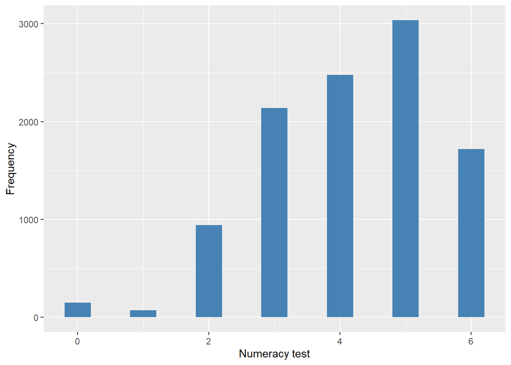

Cognition - numeracy test, composed by several numeracy questions. Discrete variable: value 0 = <=25%; value 1 = >25%

| Sample size | Missing values |
| --- | --- |
| 11050 | 516 |

Category

|  | 0 | 1 |
| --- | --- | --- |
| Frequency | 3303.00 | 7231.00 |
| Percentage | 29.89 | 65.44 |

Type of missing

|  | 991 | 992 | 993 | 994 | 995 | 996 | 997 | 998 | 999 | NA |
| --- | --- | --- | --- | --- | --- | --- | --- | --- | --- | --- |
| Frequency | 0 | 0 | 0 | 0 | 0 | 446.00 | 70.00 | 0 | 0 | 0 |
| Percentage | 0 | 0 | 0 | 0 | 0 | 4.04 | 0.63 | 0 | 0 | 0 |

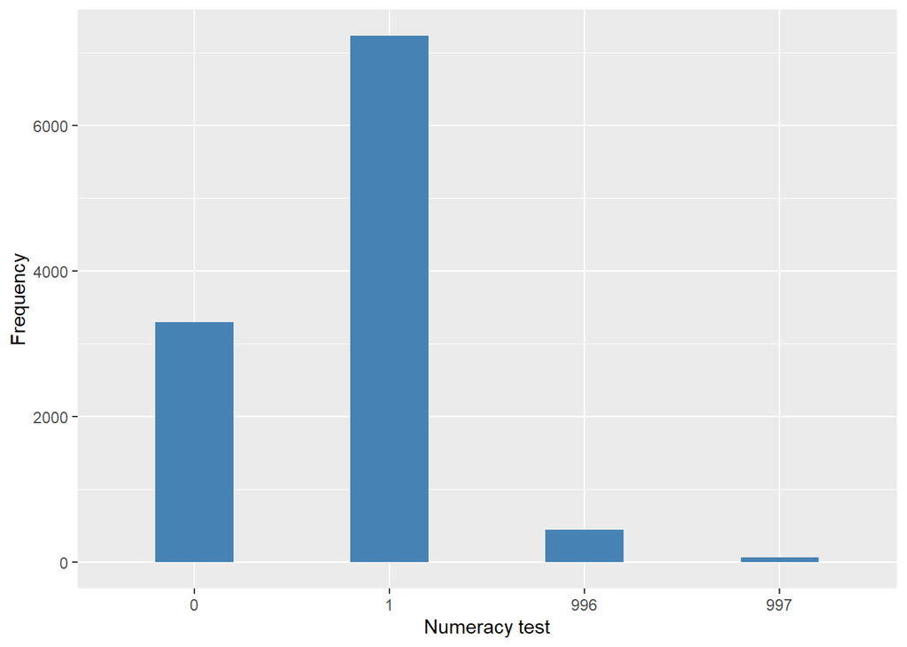

#### 2.1.4.4 Validation

### 2.1.5 Wave 5

There is no variable.

### 2.1.6 Wave 6

#### 2.1.6.1 Study-specific variable description

| **Name** | `CfMScr` |
| --- | --- |
| **Label** | `Computed score from numeracy questions (0-6)` |
| **Table name** | `wave_6_elsa_data_v2` |
| **Missings** | `-9 = Refusal` `-8 = Don't know` `-1 = Not applicable` |
| **Description** |  |

CfMScr

| Sample size | Missing values |
| --- | --- |
| 10601 | 9141 |

Values

|  | No-missings | -9 | -8 | -1 | NA |
| --- | --- | --- | --- | --- | --- |
| Frequency | 1460.00 | 0 | 0 | 9141.00 | 0 |
| Percentage | 13.77 | 0 | 0 | 86.23 | 0 |

Summary

| Min. | 1st Qu. | Median | Mean | 3rd Qu. | Max. |
| --- | --- | --- | --- | --- | --- |
| 0 | 3 | 5 | 4.408 | 6 | 6 |

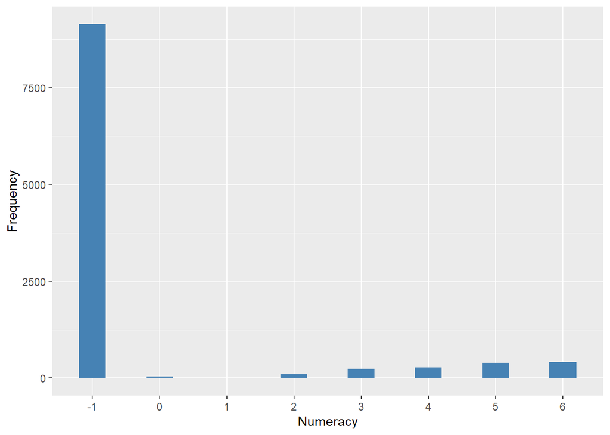

#### 2.1.6.2 Harmonisation algorithm

To compute the harmonize variable `cog_num_c` from the study-specific variable the missing values have to be recoded as follows:

- `-1 'Not applicable' into 996`
- `-9 'Refusal' into 997`
- `-8 'Don't Know' into 998`

To compute the harmonized variable `cog_num` from `cog_num_c` it has to be recoded as follows:

- `<=25% into 0`
- `>25% into 1`

**R script:**

```r
# cog_num_c
ELSA_ds_w6 <- tibble(id = ELSA_w6_cog_num$id)
ELSA_ds_w6$cog_num_c <- car::recode(ELSA_w6_cog_num$CfMScr, "-9=997; -8=998; -1=996; NA=999")
ELSA_ds_w6$cog_num_c <- labelled(ELSA_ds_w6[[2]], labels = c(Missing = 999,
    `Do not know` = 998, Refuse = 997, `Not applicable` = 996, `Does not answer` = 995,
    `Not attempt not done` = 994, `Disable to measure` = 993, Impute = 992,
    `CAPI interviewer error` = 991))

Q <- quantile(car::recode(ELSA_ds_w6$cog_num_c, "999=NA;997=NA;996=NA;998=NA"),
    probs = 1/4, na.rm = TRUE, names = FALSE)

# cog_num
ELSA_ds_w6$cog_num <- car::recode(ELSA_ds_w6$cog_num_c, "0:Q=0; (Q+1):900=1")
ELSA_ds_w6$cog_num <- labelled(ELSA_ds_w6[[3]], labels = c(`<=25%` = 0, `>25%` = 1,
    Missing = 999, `Do not know` = 998, Refuse = 997, `Not applicable` = 996,
    `Does not answer` = 995, `Not attempt not done` = 994, `Disable to measure` = 993,
    Impute = 992, `CAPI interviewer error` = 991))
```

#### 2.1.6.3 Statistical description of the new harmonised variable

Cognition - numeracy test, composed by several numeracy questions

| Sample size | Missing values |
| --- | --- |
| 10601 | 9141 |

Values

|  | No-missings | 991 | 992 | 993 | 994 | 995 | 996 | 997 | 998 | 999 | NA |
| --- | --- | --- | --- | --- | --- | --- | --- | --- | --- | --- | --- |
| Frequency | 1460.00 | 0 | 0 | 0 | 0 | 0 | 9141.00 | 0 | 0 | 0 | 0 |
| Percentage | 13.77 | 0 | 0 | 0 | 0 | 0 | 86.23 | 0 | 0 | 0 | 0 |

Summary

| Min. | 1st Qu. | Median | Mean | 3rd Qu. | Max. |
| --- | --- | --- | --- | --- | --- |
| 0 | 3 | 5 | 4.408 | 6 | 6 |

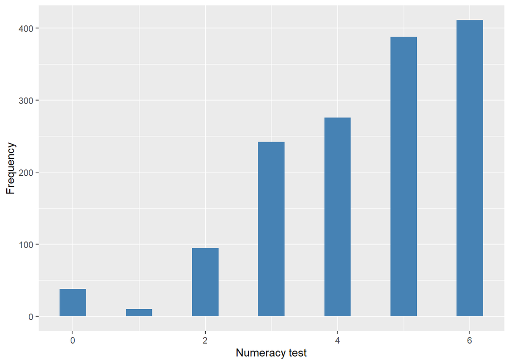

Cognition - numeracy test, composed by several numeracy questions. Discrete variable: value 0 = <=25%; value 1 = >25%

| Sample size | Missing values |
| --- | --- |
| 10601 | 9141 |

Category

|  | 0 | 1 |
| --- | --- | --- |
| Frequency | 385.00 | 1075.00 |
| Percentage | 3.63 | 10.14 |

Type of missing

|  | 991 | 992 | 993 | 994 | 995 | 996 | 997 | 998 | 999 | NA |
| --- | --- | --- | --- | --- | --- | --- | --- | --- | --- | --- |
| Frequency | 0 | 0 | 0 | 0 | 0 | 9141.00 | 0 | 0 | 0 | 0 |
| Percentage | 0 | 0 | 0 | 0 | 0 | 86.23 | 0 | 0 | 0 | 0 |

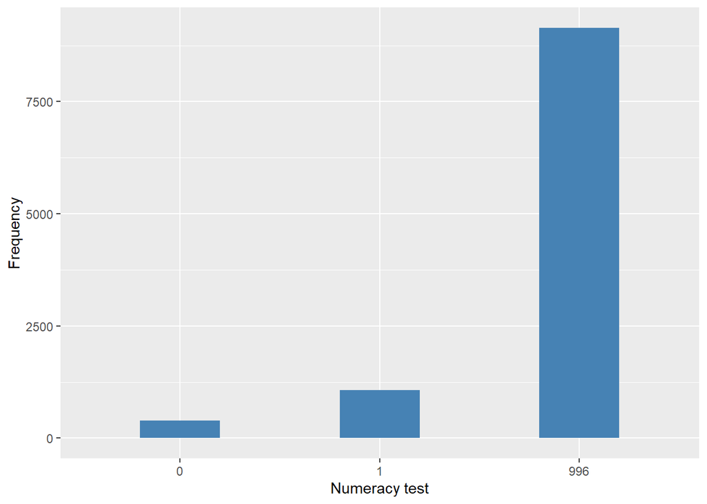

#### 2.1.6.4 Validation

### 2.1.7 Wave 7

#### 2.1.7.1 Study-specific variable description

| **Name** | `CfMScr` |
| --- | --- |
| **Label** | `Computed score from numeracy questions (0-6)` |
| **Table name** | `wave_7_elsa_data` |
| **Missings** | `-9 = Refusal` `-8 = Don't know` `-1 = Not applicable` |
| **Description** |  |

CfMScr

| Sample size | Missing values |
| --- | --- |
| 9666 | 9096 |

Values

|  | No-missings | -9 | -8 | -1 | NA |
| --- | --- | --- | --- | --- | --- |
| Frequency | 570.0 | 0 | 0 | 9096.0 | 0 |
| Percentage | 5.9 | 0 | 0 | 94.1 | 0 |

Summary

| Min. | 1st Qu. | Median | Mean | 3rd Qu. | Max. |
| --- | --- | --- | --- | --- | --- |
| 0 | 3 | 4 | 4.209 | 5 | 6 |

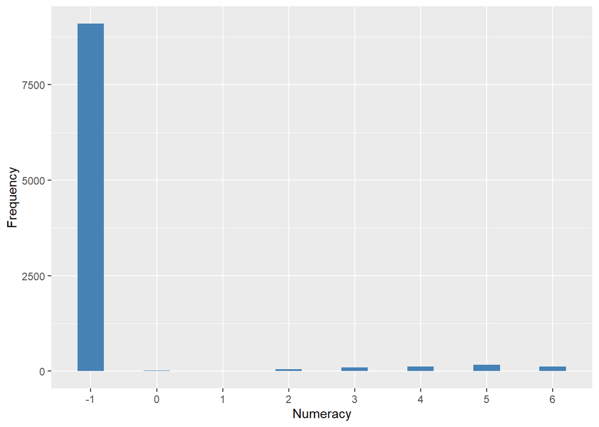

#### 2.1.7.2 Harmonisation algorithm

To compute the harmonize variable `cog_num_c` from the study-specific variable the missing values have to be recoded as follows:

- `-1 'Not applicable' into 996`
- `-9 'Refusal' into 997`
- `-8 'Don't Know' into 998`

To compute the harmonized variable `cog_num` from `cog_num_c` it has to be recoded as follows:

- `<=25% into 0`
- `>25% into 1`

**R script:**

```r
# cog_num_c
ELSA_ds_w7 <- tibble(id = ELSA_w7_cog_num$id)
ELSA_ds_w7$cog_num_c <- car::recode(ELSA_w7_cog_num$CfMScr, "-9=997; -8=998; -1=996; NA=999")
ELSA_ds_w7$cog_num_c <- labelled(ELSA_ds_w7[[2]], labels = c(Missing = 999,
    `Do not know` = 998, Refuse = 997, `Not applicable` = 996, `Does not answer` = 995,
    `Not attempt not done` = 994, `Disable to measure` = 993, Impute = 992,
    `CAPI interviewer error` = 991))

Q <- quantile(car::recode(ELSA_ds_w7$cog_num_c, "999=NA;997=NA;996=NA;998=NA"),
    probs = 1/4, na.rm = TRUE, names = FALSE)

# cog_num
ELSA_ds_w7$cog_num <- car::recode(ELSA_ds_w7$cog_num_c, "0:Q=0; (Q+1):900=1")
ELSA_ds_w7$cog_num <- labelled(ELSA_ds_w7[[3]], labels = c(`<=25%` = 0, `>25%` = 1,
    Missing = 999, `Do not know` = 998, Refuse = 997, `Not applicable` = 996,
    `Does not answer` = 995, `Not attempt not done` = 994, `Disable to measure` = 993,
    Impute = 992, `CAPI interviewer error` = 991))
```

#### 2.1.7.3 Statistical description of the new harmonised variable

Cognition - numeracy test, composed by several numeracy questions

| Sample size | Missing values |
| --- | --- |
| 9666 | 9096 |

Values

|  | No-missings | 991 | 992 | 993 | 994 | 995 | 996 | 997 | 998 | 999 | NA |
| --- | --- | --- | --- | --- | --- | --- | --- | --- | --- | --- | --- |
| Frequency | 570.0 | 0 | 0 | 0 | 0 | 0 | 9096.0 | 0 | 0 | 0 | 0 |
| Percentage | 5.9 | 0 | 0 | 0 | 0 | 0 | 94.1 | 0 | 0 | 0 | 0 |

Summary

| Min. | 1st Qu. | Median | Mean | 3rd Qu. | Max. |
| --- | --- | --- | --- | --- | --- |
| 0 | 3 | 4 | 4.209 | 5 | 6 |

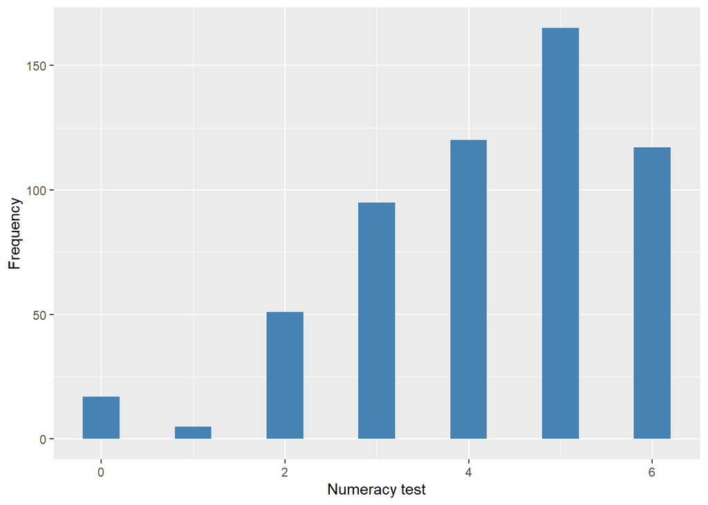

Cognition - numeracy test, composed by several numeracy questions. Discrete variable: value 0 = <=25%; value 1 = >25%

| Sample size | Missing values |
| --- | --- |
| 9666 | 9096 |

Category

|  | 0 | 1 |
| --- | --- | --- |
| Frequency | 168.00 | 402.00 |
| Percentage | 1.74 | 4.16 |

Type of missing

|  | 991 | 992 | 993 | 994 | 995 | 996 | 997 | 998 | 999 | NA |
| --- | --- | --- | --- | --- | --- | --- | --- | --- | --- | --- |
| Frequency | 0 | 0 | 0 | 0 | 0 | 9096.0 | 0 | 0 | 0 | 0 |
| Percentage | 0 | 0 | 0 | 0 | 0 | 94.1 | 0 | 0 | 0 | 0 |

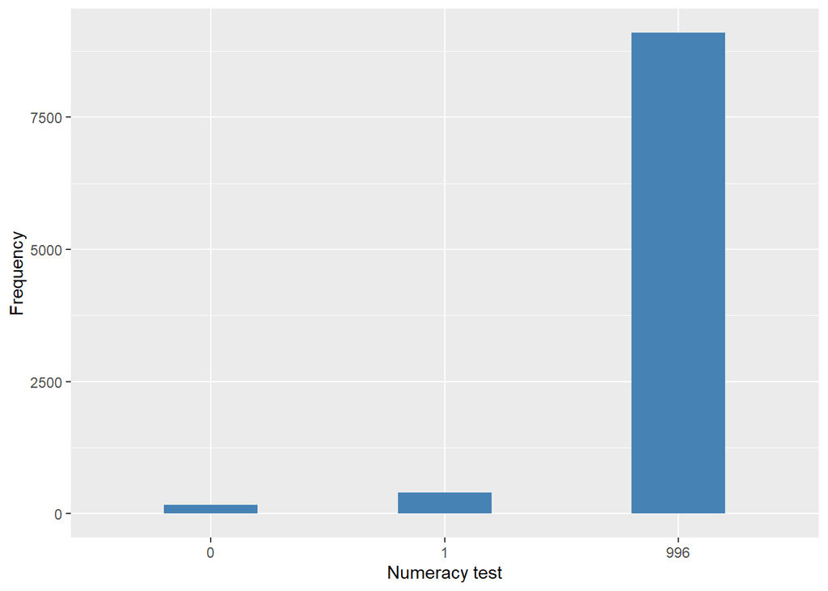

#### 2.1.7.4 Validation

## 2.2 Descriptive statistics of the harmonised variable `cog_num` accross populations and waves

Two tables are generated:

1. Percentages of categories in each harmonised variable.
2. Frequencies and percentages of individuals with different trajectories. To avoid too large table, only trajectories with percentages larger than 0.3 are shown.

Cognition - numeracy test, composed by several numeracy questions. Discrete variable: value 0 = <=25%; value 1 = >25%

| val | label | W1 | W4 | W6 | W7 |
| --- | --- | --- | --- | --- | --- |
| 0 | <=25% | 37.11 | 29.89 | 3.63 | 1.74 |
| 1 | >25% | 61.11 | 65.44 | 10.14 | 4.16 |
| 991 | CAPI interviewer error | 0 | 0 | 0 | 0 |
| 992 | Impute | 0 | 0 | 0 | 0 |
| 993 | Disable to measure | 0 | 0 | 0 | 0 |
| 994 | Not attempt not done | 0 | 0 | 0 | 0 |
| 995 | Does not answer | 0 | 0 | 0 | 0 |
| 996 | Not applicable | 1.78 | 4.04 | 86.23 | 94.1 |
| 997 | Refuse | 0 | 0.63 | 0 | 0 |
| 998 | Do not know | 0 | 0 | 0 | 0 |
| 999 | Missing | 0 | 0 | 0 | 0 |
| NA | NA | 0 | 0 | 0 | 0 |
| n | sample size | 12099 | 11050 | 10601 | 9666 |

|  | val | frq | raw.prc |
| --- | --- | --- | --- |
| 5 | 00NANA | 1437 | 7.95 |
| 9 | 01NANA | 560 | 3.10 |
| 13 | 0NANANA | 2451 | 13.55 |
| 15 | 10NANA | 780 | 4.31 |
| 21 | 11NANA | 3844 | 21.26 |
| 27 | 1NANANA | 2691 | 14.88 |
| 32 | NA0NANA | 1052 | 5.82 |
| 38 | NA1NANA | 2711 | 14.99 |
| 41 | NANA0NA | 336 | 1.86 |
| 44 | NANA1NA | 957 | 5.29 |
| 45 | NANANA0 | 143 | 0.79 |
| 46 | NANANA1 | 341 | 1.89 |
| 47 | NANANANA | 562 | 3.11 |

## 2.3 Summary of descriptive statistics of the harmonised variable `cog_num_c` accross populations and waves

Cognition - numeracy test, composed by several numeracy questions

| cog_num_c | W1 | W4 | W6 | W7 |
| --- | --- | --- | --- | --- |
| Min. | 0 | 0 | 0 | 0 |
| 1st Qu. | 3 | 3 | 3 | 3 |
| Median | 4 | 4 | 5 | 4 |
| Mean | 3.885 | 4.155 | 4.408 | 4.209 |
| 3rd Qu. | 5 | 5 | 6 | 5 |
| Max. | 6 | 6 | 6 | 6 |
| No-missings | 11884 | 10534 | 1460 | 570 |
| 991 | 0 | 0 | 0 | 0 |
| 992 | 0 | 0 | 0 | 0 |
| 993 | 0 | 0 | 0 | 0 |
| 994 | 0 | 0 | 0 | 0 |
| 995 | 0 | 0 | 0 | 0 |
| 996 | 215 | 446 | 9141 | 9096 |
| 997 | 0 | 70 | 0 | 0 |
| 998 | 0 | 0 | 0 | 0 |
| 999 | 0 | 0 | 0 | 0 |
| NA | 0 | 0 | 0 | 0 |
| sample size | 12099 | 11050 | 10601 | 9666 |

# 3 Quality estimation

Numerical ability for waves 6 and 7 only collected/assessed for refreshment sample or those who had not undertaken previously (see at [The data we collect](https://www.elsa-project.ac.uk/the-data-we-collect), or also [ELSA DATA SET WAVES 1 TO 9](https://www.ucl.ac.uk/drupal/site_iehc/sites/iehc/files/elsa_data_set_waves_1_to_9.pdf)).

[output not shown]